# ESM 204 HW 3: Social Cost of Carbon

Sarah Hamilton

5/15/2022

# 1 Estimate damages as a function of the change in global temperature

Estimated Damages Regression Function:

```r
pulse <- 35000000000

#make a new column with warming^2 to derive a quadratic model
damages$warming2 <- damages$warming^2

#run a linear regression using the new warming^2 and the original warming
damages_quad_model <- lm(damages ~ 0 + warming + warming2, data = damages)

#output the model results
#summary(damages_quad_model)

#make a function out of the model results
damages_quad_function <- function(x){
  damages_quad_model$coefficients[1]*x+damages_quad_model$coefficients[2]*x^2
}

#output equation
extract_eq(model = damages_quad_model, use_coefs = TRUE, coef_digits = 2)
```

$$\operatorname{\widehat{damages}} = -1059530137756.23(\operatorname{warming}) + 19409275730643.3(\operatorname{warming2})$$

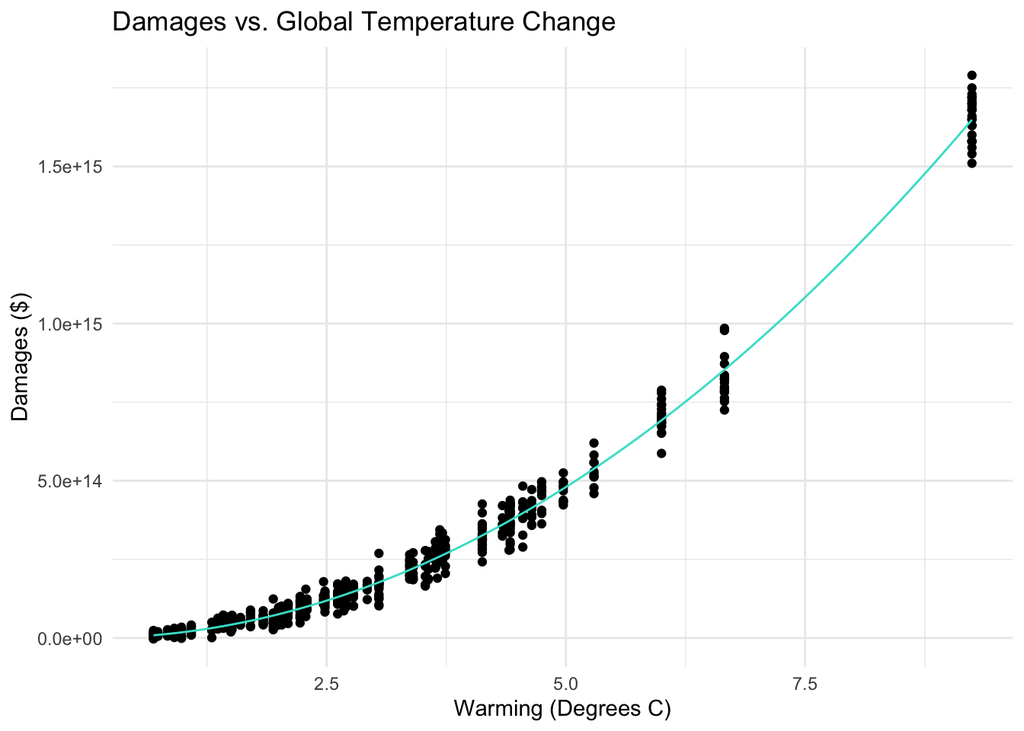

```r
#plot the raw data and the model
ggplot(data = damages, aes(x = warming, y = damages)) +
  geom_point() +
  theme_minimal() +
  labs(x = "Warming (Degrees C)", y = "Damages ($)", title = "Damages vs. Global Temperature Change") +
  stat_function(fun = damages_quad_function, color = "turquoise")
```

Figure 1. The above plot shows the damages that result from given amounts of warming.

# 2 Estimated damages under different scenarios

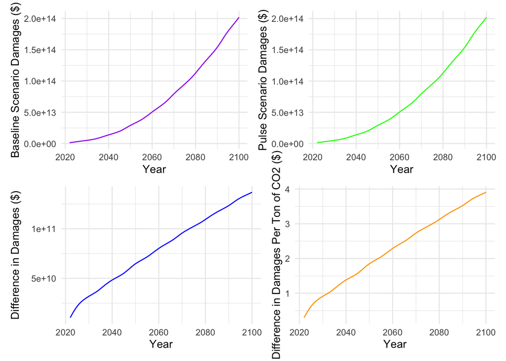

```r
warming_damages <- warming %>%
  mutate(damages_baseline = damages_quad_function(warming_baseline)) %>%
  mutate(damages_pulse = damages_quad_function(warming_pulse)) %>%
  mutate(damages_difference = damages_pulse - damages_baseline) %>%
  mutate(damages_difference_co2 = damages_difference/pulse)

plot_damages_no_pulse <- ggplot(data = warming_damages, aes(x = year, y = damages_baseline)) +
  geom_line(color = "purple") +
  theme_minimal() +
  labs(x = "Year", y = "Baseline Scenario Damages ($)")

plot_damages_pulse <- ggplot(data = warming_damages, aes(x = year, y = damages_pulse)) +
  geom_line(color = "green") +
  theme_minimal() +
  labs(x = "Year", y = "Pulse Scenario Damages ($)")

plot_damages_difference <- ggplot(data = warming_damages, aes(x = year, y = damages_difference)) +
  geom_line(color = "blue") +
  theme_minimal() +
  labs(x = "Year", y = "Difference in Damages ($)")

plot_damages_difference_co2 <- ggplot(data = warming_damages, aes(x = year, y = damages_difference_co2)) +
  geom_line(color = "orange") +
  theme_minimal() +
  labs(x = "Year", y = "Difference in Damages Per Ton of CO2 ($)")


(plot_damages_no_pulse+plot_damages_pulse)/(plot_damages_difference+plot_damages_difference_co2)
```

Figure 2. The above plots represent the damages caused by CO2 emissions each year under two scenarios. The top left shows the damages that result each year under the baseline scenario of warming. The top right shows the damages that result each year under the pulse scenario of warming. The bottom left shows the difference in damages between the two scenarios. The bottom right shows the difference in damages that results between the two scenarios per ton of additional CO2 emitted from the pulse.

# 3 Social cost of carbon

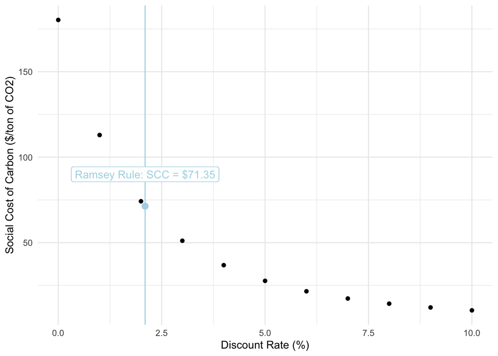

```r
baseline_year <- 2022

warming_damages_scc <- warming_damages %>%
  select(year, damages_difference_co2) %>%
  mutate(pv_0 = damages_difference_co2*((1+0.0)^(-(year-baseline_year)))) %>%
  mutate(pv_1 = damages_difference_co2*((1+0.01)^(-(year-baseline_year)))) %>%
  mutate(pv_2 = damages_difference_co2*((1+0.02)^(-(year-baseline_year)))) %>%
  mutate(pv_3 = damages_difference_co2*((1+0.03)^(-(year-baseline_year)))) %>%
  mutate(pv_4 = damages_difference_co2*((1+0.04)^(-(year-baseline_year)))) %>%
  mutate(pv_5 = damages_difference_co2*((1+0.05)^(-(year-baseline_year)))) %>%
  mutate(pv_6 = damages_difference_co2*((1+0.06)^(-(year-baseline_year)))) %>%
  mutate(pv_7 = damages_difference_co2*((1+0.07)^(-(year-baseline_year)))) %>%
  mutate(pv_8 = damages_difference_co2*((1+0.08)^(-(year-baseline_year)))) %>%
  mutate(pv_9 = damages_difference_co2*((1+0.09)^(-(year-baseline_year)))) %>%
  mutate(pv_10 = damages_difference_co2*((1+0.1)^(-(year-baseline_year))))

disc_rates <- c(0,1,2,3,4,5,6,7,8,9,10)
scc_calc <- c(sum(warming_damages_scc$pv_0),sum(warming_damages_scc$pv_1),
                       sum(warming_damages_scc$pv_2),sum(warming_damages_scc$pv_3),
                       sum(warming_damages_scc$pv_4),sum(warming_damages_scc$pv_5),
                       sum(warming_damages_scc$pv_6),sum(warming_damages_scc$pv_7),
                       sum(warming_damages_scc$pv_8),sum(warming_damages_scc$pv_9),
                       sum(warming_damages_scc$pv_10))
scc_df <- data.frame(disc_rates,
                     scc_calc)


ggplot(data = scc_df, aes(x = disc_rates, y = scc_calc)) +
  geom_point(color = "black") +
  theme_minimal() +
  labs(x = "Discount Rate (%)", y = "Social Cost of Carbon ($/ton of CO2)") +
  geom_vline(xintercept=2.1, color = 'light blue') +
  geom_label(aes(x=2.1, label="Ramsey Rule: SCC = $71.35", y=90), colour="light blue", angle=90) +
  geom_point(aes(x = 2.1, y = 71.35), color = "light blue", size = 2.5)
```

```r
# scc_function <- function(discount_rate){
#   warming_damages_scc %>%
#     mutate(pv = damages_difference_co2/((1+discount_rate)^(-(year-baseline_year))))
#   present_value = sum(warming_damages_scc$pv)
#   return(present_value)
# }
```

# 4 Ramsey Rule for SCC

```r
#Use the ramsey rule to calculate the discount rate for SCC
discount_rate_ramsey <- (0.001+2*0.01)*100

warming_damages_ramsey <- warming_damages %>%
  select(year, damages_difference_co2) %>%
  mutate(pv_ramsey = damages_difference_co2*((1+(discount_rate_ramsey/100))^(-(year-baseline_year))))

scc_ramsey <- sum(warming_damages_ramsey$pv_ramsey)
```

When using the Ramsey Rule, the discount rate we should use to calculate the SCC would be 2.1%, and the resulting SCC would be 71.35 dollars. This point is marked on the plot above where the blue vertical line intercepts the curve.

# 5 Policy Analysis

```r
discount_rate_policy <- 0.02
#assume society is risk neutral

#Policy A
warming_damages_policy_a <- warming_damages %>%
  select(year, warming_baseline, damages_baseline) %>%
  mutate(damages_2 = damages_quad_function(1.5*warming_baseline)) %>%
  mutate(pv_baseline = damages_baseline*(1+discount_rate_policy)^(-(year-baseline_year))) %>%
  mutate(pv_2 = damages_2*(1+discount_rate_policy)^(-(year-baseline_year)))

p_a_1 <- 0.5
p_a_2 <- 0.5
ev_a_1 <- sum(warming_damages_policy_a$pv_baseline)
ev_a_2 <- sum(warming_damages_policy_a$pv_2)

ev_a <- p_a_1*ev_a_1+p_a_2*ev_a_2 #expected present value of damages up to 2100 policy A in dollars

#Policy B
warming_damages_policy_b <- warming_damages %>%
  select(year, warming_baseline)

for (i in 30:79){
  warming_damages_policy_b$warming_baseline[i]=1.29
}

warming_damages_policy_b <- warming_damages_policy_b %>%
  mutate(damages_b = damages_quad_function(warming_baseline)) %>%
  mutate(pv_b = damages_b*(1+discount_rate_policy)^(-(year-baseline_year)))

p_b <- 1.0
ev_b <- sum(warming_damages_policy_b$pv_b)*p_b #expected present value of damages up to 2100 policy B in dollars
```

Policy A: Business as Usual

The expected present value of damages up to 2100 of policy A is 3.0232455^{15} dollars.

Policy B: Take Immediate Action on Climate Change

The expected present value of damages up to 2100 of policy B is 7.8667128^{14} dollars.

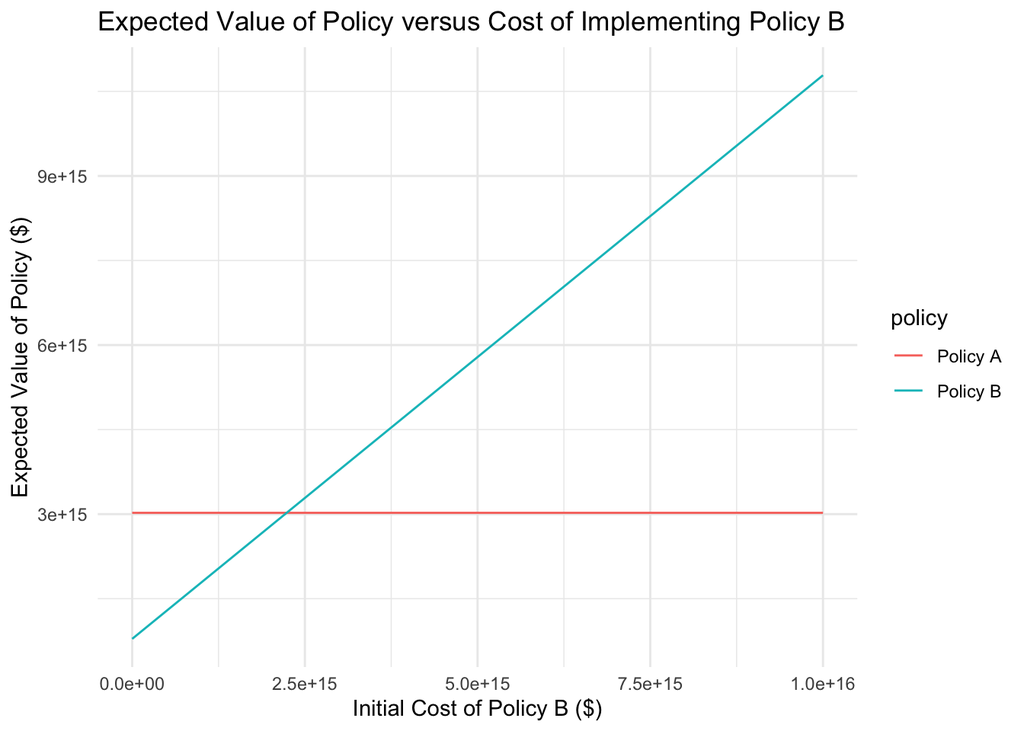

```r
policy_a_cost <- function(x){ev_a}
policy_b_cost <- function(x){ev_b+x}

costs <- c(0,1e15,2e15,3e15,4e15,5e15,6e15,7e15,8e15,9e15,10e15)
total_cost_a <- c(NA,NA,NA,NA,NA,NA,NA,NA,NA,NA,NA)
total_cost_b <- c(NA,NA,NA,NA,NA,NA,NA,NA,NA,NA,NA)

cost_df <- data.frame(costs,total_cost_a,total_cost_b)

cost_df <- cost_df %>%
  mutate(total_cost_a = policy_a_cost(costs)) %>%
  mutate(total_cost_b = policy_b_cost(costs))

costs_df_long <- cost_df %>%
  pivot_longer(cols = c(total_cost_a,total_cost_b), names_to = 'policy', values_to = 'total_cost') %>%
  mutate(policy = case_when(
    policy == "total_cost_a" ~ "Policy A",
    policy == "total_cost_b" ~ "Policy B"
  ))

ggplot(data = costs_df_long, aes(x = costs, y = total_cost)) +
  geom_line(aes(color = policy)) +
  theme_minimal() +
  labs(x = "Initial Cost of Policy B ($)", y = "Expected Value of Policy ($)",
       title = "Expected Value of Policy versus Cost of Implementing Policy B")
```

```r
#find point where policy a cost = policy b cost using uniroot()

dif_costs_fun <- function(x){ev_a-(ev_b+x)}
equal_cost <- uniroot(dif_costs_fun, c(1e15,2.5e15))$root
```

Figure 4. The above plot shows the expected value of policies A and B as a function of the initial cost of implementing Policy B (Policy A has no initial costs).

The two policies have the same total expected value when the initial cost of Policy B is 2.2365743^{15} dollars. Therefore, if Policy B costs less than this amount, Congress should undertake Policy B, and if Policy B costs more than this amount, Congress should undertake Policy A (assuming that cost is their only consideration).

# 6 Risk Averse Society

If society is risk averse, they are less likely to want to take the risk that Policy A results in the lower cost scenario, or in other words, they are more likely to prefer Policy B because it has guaranteed lower future damages than the high cost outcome from Policy A. Therefore, if we determined that society is risk averse, I would advise Congress to model society’s utility function from given monetary costs, then plug in the estimated costs of policies A and B into the utility function, and then recalculate the expected costs (or damages) of each policy using these new expected utility values. After this, they should determine the cost of Policy B, add it to the expected costs (or damages) of Policy B and then determine which policy has the lowest expected costs (or damages) and choose that policy.